# Etude de la qualité de l’air en Occitanie

Projet UE 403 - Statistique descriptive

Projet Informatique-Statistique 2025-2026

# 1 Introduction

Ce rapport propose une analyse de la qualité de l’air en Occitanie à travers quatre problématiques, à partir de la description des données extraites de notre base contenant les informations de pollution, météorologiques, géographiques et socio-économiques des 13 régions de France.

# 2 Creation de la base de donnees

## 2.1 Observation des fichiers de donnees

Les trois fichiers CSV fournis presentent plusieurs problemes de normalisation. Le diagramme ci-dessous resume les problemes identifies dans chaque fichier (marques par un X en rouge) et les tables normalisees correspondantes (en vert a droite).

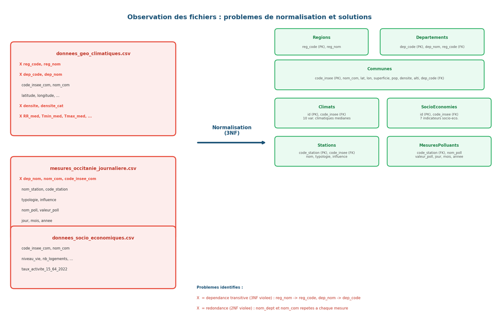

Problemes de normalisation identifies dans les fichiers CSV et solutions adoptees

Les donnees issues des fichiers CSV geo_climatiques et mesures_journaliers presentent des redondances et des dependances transitives qui contreviennent a la Troisieme Forme Normale (3NF). En l’etat, ces fichiers ne respectent pas les contraintes du modele relationnel et ne peuvent donc pas etre integres directement comme entites dans notre base de donnees sans une phase prealable de normalisation.

## 2.2 Normalisation et modele relationnel

Pour resoudre ces problemes, les donnees ont ete decomposees en 7 tables normalisees. Le diagramme Entite-Relation ci-dessous presente le schema de la base de donnees apres normalisation, avec les cles primaires (PK en rouge), les cles etrangeres (FK en bleu) et les cardinalites entre les tables.

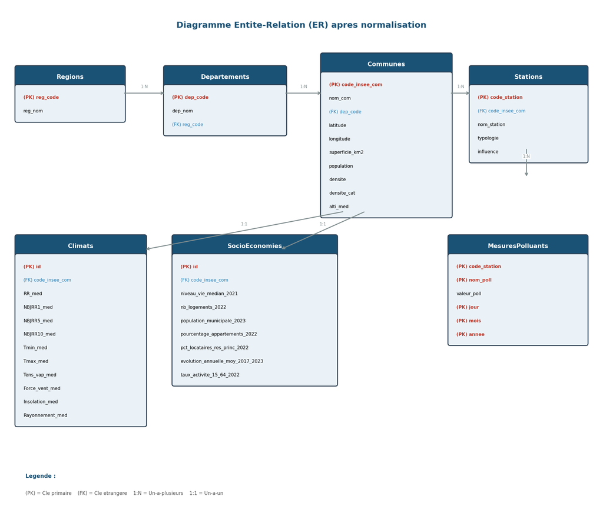

Diagramme Entite-Relation (ER) de la base de donnees apres normalisation

La table Regions contient reg_code (PK) et reg_nom, ce qui elimine la dependance transitive presente dans le fichier geo_climatiques. La table Departements contient dep_code (PK), dep_nom et reg_code (FK vers Regions). La table Communes regroupe les attributs geographiques propres a la commune : code_insee_com (PK), nom_com, latitude, longitude, superficie_km2, population, densite, densite_cat, alti_med et dep_code (FK). La table Climats separe les 10 variables climatiques medianes, rattachees a la commune par code_insee_com (FK). La table SocioEconomies contient les 7 indicateurs socio-economiques par commune. La table Stations isole les informations propres a chaque station de mesure : code_station (PK), code_insee_com (FK), nom_station, typologie et influence. Enfin, la table MesuresPolluants stocke les mesures journalieres avec une cle primaire composite (code_station, nom_poll, jour, mois, annee).

Ce schema respecte la 3NF : chaque attribut non-cle depend uniquement de la cle primaire de sa table, sans dependance transitive.

## 2.3 Diagramme d’activites

Le programme Python (projet_stat.py) s’execute en 5 phases successives representees dans le diagramme d’activites ci-dessous.

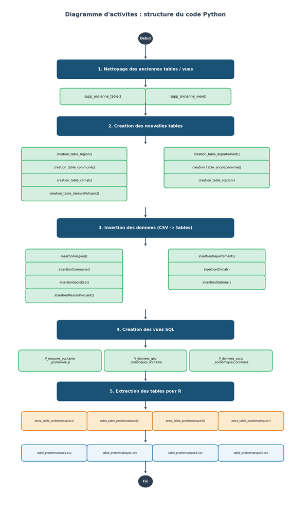

Diagramme d’activites : structure du code Python

Phase 1 (Nettoyage) : les fonctions supp_ancienne_table() et supp_ancienne_view() suppriment toutes les tables et vues existantes pour repartir d’une base propre a chaque execution.

Phase 2 (Creation des tables) : les 7 tables sont creees dans un ordre qui respecte les contraintes de cles etrangeres, en commencant par Regions puis Departements, Communes, SocioEconomies, Climats, Stations, et enfin MesuresPolluants.

Phase 3 (Insertion des donnees) : les trois fichiers CSV sont lus avec le module csv.DictReader de Python. Pour chaque fichier, les donnees sont reparties dans les tables correspondantes. Un mecanisme de deduplication (ensemble Python de cles deja vues) empeche les doublons pour les tables Regions, Departements, Communes et Stations. La clause INSERT OR IGNORE assure egalement qu’aucun doublon ne sera insere en base.

Phase 4 (Creation des vues) : trois vues SQL sont creees pour reconstituer les fichiers CSV d’origine a partir des tables normalisees. Ces vues (V_mesures_occitanie_journaliere_p, V_donnees_geo_climatiques_occitanie, V_donnees_socio_economiques_occitanie) joignent les tables necessaires et filtrent sur la region Occitanie. Elles facilitent l’ecriture des requetes d’extraction.

Phase 5 (Extraction) : quatre requetes SQL extraient les donnees necessaires a chaque problematique statistique et les exportent en fichiers CSV.

## 2.4 Explication des requetes SQL pour repondre aux problematiques statistiques

Chaque problematique necessite une requete SQL specifique executee sur les vues reconstituees.

Problematique 1 (urbanisation et pollution) : la requete selectionne les colonnes typologie, influence et valeur_poll depuis la vue V_mesures_occitanie_journaliere_p, en filtrant sur le polluant NO2 et l’annee 2023. Cette requete produit une table ou chaque ligne correspond a une mesure journaliere de NO2 avec le type de station associe, ce qui permet de comparer les distributions de concentration selon la typologie et l’influence.

```
SELECT typologie, influence, valeur_poll
FROM V_mesures_occitanie_journaliere_p
WHERE nom_poll = 'NO2'
  AND annee = 2023;
```

Problematique 2 (saisonnalite) : la requete selectionne mois, nom_poll et valeur_poll, en filtrant sur Toulouse, les stations Urbaine/Fond, l’annee 2023, et les polluants NOX et O3. Cette restriction permet de comparer l’evolution mensuelle des concentrations de deux polluants dans un meme environnement de mesure.

```
SELECT mois, nom_poll, valeur_poll
FROM V_mesures_occitanie_journaliere_p
WHERE nom_com = 'Toulouse'
  AND typologie = 'Urbaine'
  AND influence = 'Fond'
  AND annee = 2023
  AND nom_poll IN ('NOX', 'O3');
```

Problematique 3 (niveau de vie et pollution) : la requete utilise une sous-requete pour calculer la moyenne de NO2 par commune (AVG(valeur_poll) AS no2_moy, avec GROUP BY code_insee_com), puis joint le resultat avec la vue socio-economique pour obtenir les indicateurs niveau_vie_median_2021, pourcentage_locataires_residence_principale_2022 et taux_activite_15_64_2022 par commune.

```
SELECT m.nom_com, m.no2_moy,
       s.niveau_vie_median_2021,
       s.pourcentage_locataires_residence_principale_2022,
       s.taux_activite_15_64_2022
FROM (SELECT code_insee_com, nom_com, AVG(valeur_poll) AS no2_moy
      FROM V_mesures_occitanie_journaliere_p
      WHERE nom_poll = 'NO2' AND annee = 2023
      GROUP BY code_insee_com, nom_com) AS m
JOIN V_donnees_socio_economiques_occitanie AS s
  ON m.code_insee_com = s.code_insee_com;
```

Problematique 4 (conditions geo-climatiques et pollution) : la requete reprend la meme sous-requete de moyenne de NO2 par commune, puis la joint avec la vue geo-climatique pour obtenir les variables alti_med, Force_vent_med, Tmax_med, Insolation_med, RR_med et densite.

```
SELECT m.code_insee_com, m.nom_com, m.no2_moy,
       cl.alti_med, cl.Force_vent_med, cl.Tmax_med,
       cl.Insolation_med, cl.RR_med, cl.densite
FROM (SELECT code_insee_com, nom_com, AVG(valeur_poll) AS no2_moy
      FROM V_mesures_occitanie_journaliere_p
      WHERE nom_poll = 'NO2' AND annee = 2023
      GROUP BY code_insee_com, nom_com) AS m
JOIN V_donnees_geo_climatiques_occitanie AS cl
  ON m.code_insee_com = cl.code_insee_com;
```

# 3 Analyse statistique des tables de données extraites de notre base de données

# 4 Chargement des donnees

```r
pb1 <- read.csv("C:/Users/ANGE/Desktop/Info/projet_stat/données/table_problematique1.csv", stringsAsFactors = TRUE)
pb2 <- read.csv("C:/Users/ANGE/Desktop/Info/projet_stat/données/table_problematique2.csv", stringsAsFactors = TRUE)
pb3 <- read.csv("C:/Users/ANGE/Desktop/Info/projet_stat/données/table_problematique3.csv", stringsAsFactors = TRUE)
pb4 <- read.csv("C:/Users/ANGE/Desktop/Info/projet_stat/données/table_problematique4.csv", stringsAsFactors = TRUE)

cat("Table 1 (urbanisation et pollution) :", nrow(pb1), "observations\n")
```

```
## Table 1 (urbanisation et pollution) : 10097 observations
```

```r
cat("Table 2 (saisonnalité) :", nrow(pb2), "observations\n")
```

```
## Table 2 (saisonnalité) : 1742 observations
```

```r
cat("Table 3 (niveau de vie) :", nrow(pb3), "communes\n")
```

```
## Table 3 (niveau de vie) : 20 communes
```

```r
cat("Table 4 (géo-climatique) :", nrow(pb4), "communes\n")
```

```
## Table 4 (géo-climatique) : 20 communes
```

# 5 Problématique 1 : L’urbanisation influence-t-elle les niveaux de pollution au NO2 ?

## 5.1 Affinement de la problématique

On se restreint au polluant NO2 pour l’année 2023, sur l’ensemble des stations d’Occitanie. On compare la distribution de valeur_poll selon les modalités de typologie (Urbaine, Périurbaine, Rurale Nationale) et de influence (Fond, Trafic, Industrielle).

## 5.2 Résumé de la table

```r
summary(pb1)
```

```
##             typologie           influence     valeur_poll
##  Périurbaine     :1775   Fond        :5897   Min.   : 0.08
##  Rurale Nationale: 326   Industrielle: 576   1st Qu.: 6.10
##  Urbaine         :7996   Trafic      :3624   Median :11.60
##                                              Mean   :16.64
##                                              3rd Qu.:23.00
##                                              Max.   :91.70
```

## 5.3 Concentration de NO2 par typologie

```r
stats_typo <- do.call(rbind, lapply(levels(pb1$typologie), function(t) {
  x <- pb1$valeur_poll[pb1$typologie == t]
  data.frame(Typologie = t, N = length(x),
    Moyenne = round(mean(x, na.rm = TRUE), 2),
    Mediane = round(median(x, na.rm = TRUE), 2),
    Ecart_type = round(sd(x, na.rm = TRUE), 2),
    Q1 = round(quantile(x, 0.25, na.rm = TRUE), 2),
    Q3 = round(quantile(x, 0.75, na.rm = TRUE), 2),
    Min = round(min(x, na.rm = TRUE), 2),
    Max = round(max(x, na.rm = TRUE), 2))
}))
print(stats_typo, row.names = FALSE)
```

```
##         Typologie    N Moyenne Mediane Ecart_type  Q1    Q3  Min   Max
##       Périurbaine 1775    9.70    7.50       7.54 4.6 12.30 0.90 48.90
##  Rurale Nationale  326    0.49    0.44       0.26 0.3  0.62 0.08  1.62
##           Urbaine 7996   18.84   13.90      15.01 7.3 26.40 0.70 91.70
```

## 5.4 Boîtes à moustaches : NO2 selon la typologie

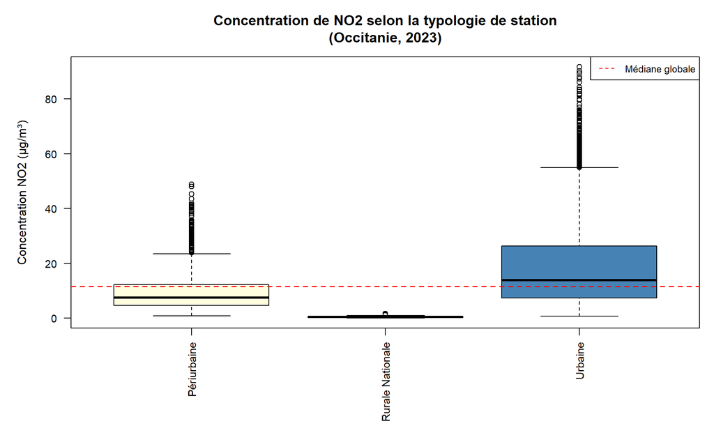

```r
par(mar = c(7, 5, 4, 1))
boxplot(valeur_poll ~ typologie, data = pb1,
        col = c("lightyellow", "lightgreen", "steelblue"),
        main = "Concentration de NO2 selon la typologie de station\n(Occitanie, 2023)",
        ylab = "Concentration NO2 (µg/m³)", xlab = "", las = 2, cex.axis = 0.9)
abline(h = median(pb1$valeur_poll, na.rm = TRUE), col = "red", lty = 2, lwd = 1.5)
legend("topright", legend = "Médiane globale", col = "red", lty = 2, cex = 0.8)
```

On observe sur les boîtes à moustaches que la distribution des concentrations de NO2 est nettement plus élevée pour les stations urbaines que pour les stations périurbaines et rurales. La médiane urbaine dépasse la médiane globale (ligne rouge), tandis que celle des stations rurales nationales se situe bien en dessous. L’étendue interquartile est également plus grande pour les stations urbaines, ce qui indique une plus forte dispersion des valeurs.

## 5.5 Statistiques descriptives par influence

```r
stats_infl <- do.call(rbind, lapply(levels(pb1$influence), function(i) {
  x <- pb1$valeur_poll[pb1$influence == i]
  data.frame(Influence = i, N = length(x),
    Moyenne = round(mean(x, na.rm = TRUE), 2),
    Mediane = round(median(x, na.rm = TRUE), 2),
    Ecart_type = round(sd(x, na.rm = TRUE), 2),
    Q1 = round(quantile(x, 0.25, na.rm = TRUE), 2),
    Q3 = round(quantile(x, 0.75, na.rm = TRUE), 2))
}))
print(stats_infl, row.names = FALSE)
```

```
##     Influence    N Moyenne Mediane Ecart_type   Q1    Q3
##          Fond 5897   10.43    8.00       8.14  4.6 14.20
##  Industrielle  576   10.77    9.10       6.04  6.7 13.12
##        Trafic 3624   27.67   25.05      16.70 13.7 39.30
```

## 5.6 Boîtes à moustaches : NO2 selon l’influence

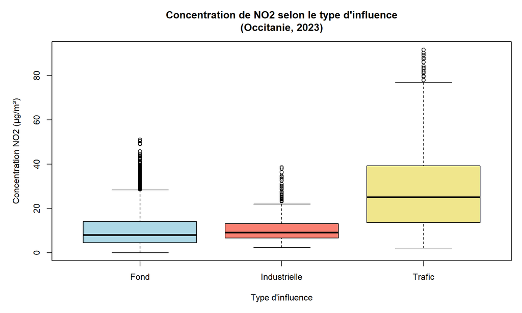

```r
par(mar = c(5, 5, 4, 1))
boxplot(valeur_poll ~ influence, data = pb1,
        col = c("lightblue", "salmon", "khaki"),
        main = "Concentration de NO2 selon le type d'influence\n(Occitanie, 2023)",
        ylab = "Concentration NO2 (µg/m³)", xlab = "Type d'influence")
```

## 5.7 Boîtes à moustaches NO2 croisées : typologie × influence

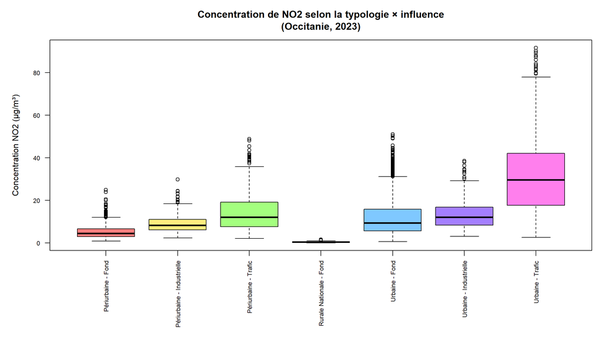

```r
pb1$type_station <- paste(pb1$typologie, "-", pb1$influence)
par(mar = c(10, 5, 4, 1))
boxplot(valeur_poll ~ type_station, data = pb1,
        col = rainbow(length(unique(pb1$type_station)), alpha = 0.5),
        main = "Concentration de NO2 selon la typologie × influence\n(Occitanie, 2023)",
        ylab = "Concentration NO2 (µg/m³)", xlab = "", las = 2, cex.axis = 0.75)
```

Le croisement des deux variables permet de distinguer plus finement les situations. La combinaison (Urbaine - Trafic) présente la médiane et l’étendue interquartile les plus élevées de toutes les combinaisons. La combinaison (Rurale Nationale - Fond) se situe à l’autre extrémité, avec des valeurs très basses et une dispersion quasi nulle. On remarque aussi que, pour une même typologie, la modalité (Trafic) produit systématiquement des distributions décalées vers le haut par rapport à la modalité (Fond).

## 5.8 Histogrammes comparés : fond urbain vs trafic urbain

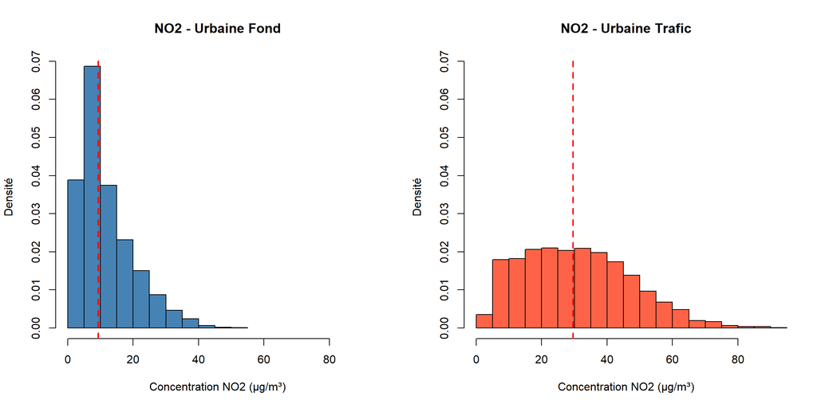

```r
fond_urb <- pb1$valeur_poll[pb1$typologie == "Urbaine" & pb1$influence == "Fond"]
trafic_urb <- pb1$valeur_poll[pb1$typologie == "Urbaine" & pb1$influence == "Trafic"]

h1 <- hist(fond_urb, plot = FALSE)
h2 <- hist(trafic_urb, plot = FALSE)
xlim <- c(0, max(c(fond_urb, trafic_urb), na.rm = TRUE))
ylim <- range(c(0, h1$density, h2$density))

par(mfrow = c(1, 2))
hist(fond_urb, probability = TRUE, col = "steelblue", xlim = xlim, ylim = ylim,
     main = "NO2 - Urbaine Fond", xlab = "Concentration NO2 (µg/m³)", ylab = "Densité")
abline(v = median(fond_urb), col = "red", lwd = 2, lty = 2)
hist(trafic_urb, probability = TRUE, col = "tomato", xlim = xlim, ylim = ylim,
     main = "NO2 - Urbaine Trafic", xlab = "Concentration NO2 (µg/m³)", ylab = "Densité")
abline(v = median(trafic_urb), col = "red", lwd = 2, lty = 2)
```

```r
par(mfrow = c(1, 1))
```

```r
cat("Résumé comparatif :\n")
```

```
## Résumé comparatif :
```

```r
cat("  Fond urbain   - médiane =", round(median(fond_urb), 1), "µg/m³, moyenne =", round(mean(fond_urb), 1), "µg/m³\n")
```

```
##   Fond urbain   - médiane = 9.3 µg/m³, moyenne = 11.8 µg/m³
```

```r
cat("  Trafic urbain - médiane =", round(median(trafic_urb), 1), "µg/m³, moyenne =", round(mean(trafic_urb), 1), "µg/m³\n")
```

```
##   Trafic urbain - médiane = 29.6 µg/m³, moyenne = 30.9 µg/m³
```

```r
cat("  Rapport des médianes (trafic/fond) =", round(median(trafic_urb) / median(fond_urb), 1), "\n")
```

```
##   Rapport des médianes (trafic/fond) = 3.2
```

## 5.9 Conclusion de la problématique 1

D’un point de vue statistique, les distributions de NO2 diffèrent fortement selon la modalité de la variable typologie et selon la modalité de la variable influence. Les indicateurs de position (moyenne, médiane) et de dispersion (écart-type, étendue interquartile) sont systématiquement plus élevés pour la modalité (Urbaine) que pour (Périurbaine) et (Rurale Nationale). De même, la modalité (Trafic) présente des valeurs nettement supérieures à la modalité (Fond). Le croisement des deux variables montre que la combinaison (Urbaine - Trafic) concentre les valeurs les plus élevées. Ces différences entre les distributions sont clairement visibles sur les boîtes à moustaches et les histogrammes.

# 6 Problématique 2 : Observe-t-on une saisonnalité de la pollution selon le polluant ?

## 6.1 Affinement de la problématique

On se restreint à la commune de Toulouse, aux stations de type Urbaine avec une influence Fond, pour l’année 2023. On compare la distribution mensuelle de valeur_poll pour deux polluants : NOX et O3.

## 6.2 Résumé de la table

```r
summary(pb2)
```

```
##       mois        nom_poll    valeur_poll
##  Min.   : 1.000   NOX: 693   Min.   :  3.00
##  1st Qu.: 4.000   O3 :1049   1st Qu.: 15.32
##  Median : 7.000              Median : 43.00
##  Mean   : 6.579              Mean   : 42.02
##  3rd Qu.:10.000              3rd Qu.: 63.20
##  Max.   :12.000              Max.   :174.70
```

## 6.3 Boîtes à moustaches mensuelles : NOX

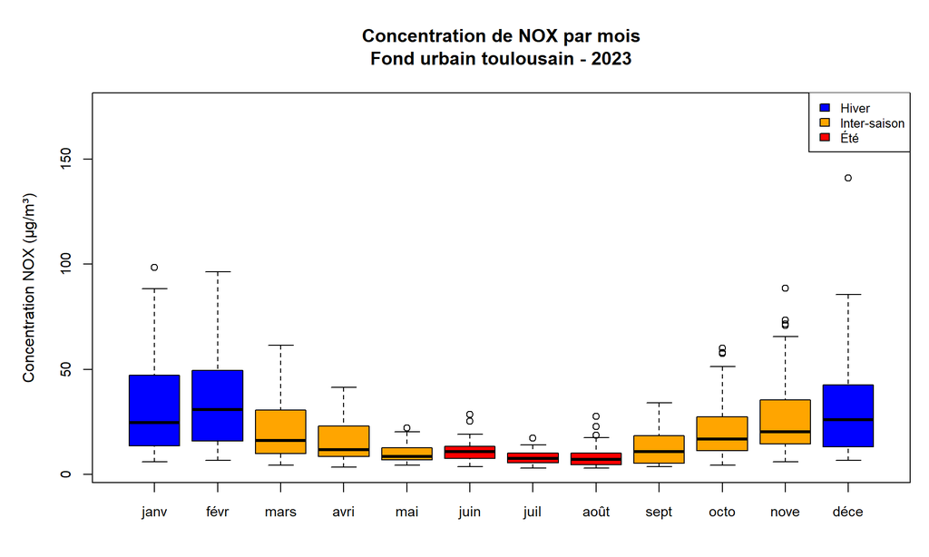

```r
pb2_nox <- pb2[pb2$nom_poll == "NOX", ]
mois_abb <- c("janv", "févr", "mars", "avri", "mai", "juin",
              "juil", "août", "sept", "octo", "nove", "déce")
couleurs_saison <- c("blue", "blue", "orange", "orange", "orange", "red",
                     "red", "red", "orange", "orange", "orange", "blue")

par(mar = c(4, 5, 5, 1))
boxplot(valeur_poll ~ mois, data = pb2_nox,
        col = couleurs_saison, names = mois_abb,
        main = "Concentration de NOX par mois\nFond urbain toulousain - 2023",
        ylab = "Concentration NOX (µg/m³)", xlab = "", cex.axis = 0.9)
legend("topright", legend = c("Hiver", "Inter-saison", "Été"),
       fill = c("blue", "orange", "red"), cex = 0.8)
```

## 6.4 Boîtes à moustaches mensuelles : O3

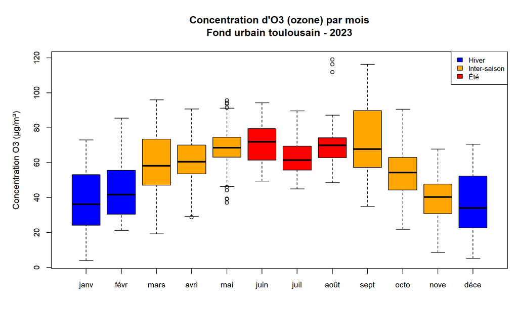

```r
pb2_o3 <- pb2[pb2$nom_poll == "O3", ]

par(mar = c(4, 5, 5, 1))
boxplot(valeur_poll ~ mois, data = pb2_o3,
        col = couleurs_saison, names = mois_abb,
        main = "Concentration d'O3 (ozone) par mois\nFond urbain toulousain - 2023",
        ylab = "Concentration O3 (µg/m³)", xlab = "", cex.axis = 0.9)
legend("topright", legend = c("Hiver", "Inter-saison", "Été"),
       fill = c("blue", "orange", "red"), cex = 0.8)
```

## 6.5 Tableau des médianes mensuelles par polluant

```r
med_nox <- aggregate(valeur_poll ~ mois, data = pb2_nox, FUN = median)
med_o3 <- aggregate(valeur_poll ~ mois, data = pb2_o3, FUN = median)
tab_med <- merge(med_nox, med_o3, by = "mois", suffixes = c("_NOX", "_O3"))
tab_med$mois_nom <- mois_abb
tab_med <- tab_med[order(tab_med$mois), ]
colnames(tab_med) <- c("Mois", "Médiane NOX", "Médiane O3", "Mois (nom)")
print(tab_med[, c("Mois (nom)", "Médiane NOX", "Médiane O3")], row.names = FALSE)
```

```
##  Mois (nom) Médiane NOX Médiane O3
##        janv       24.70      36.20
##        févr       30.75      41.70
##        mars       16.10      58.15
##        avri       11.80      60.60
##         mai        8.50      68.50
##        juin       10.90      71.90
##        juil        7.60      61.50
##        août        7.25      69.90
##        sept       10.85      67.80
##        octo       16.75      54.30
##        nove       20.35      40.40
##        déce       26.05      34.00
```

Le tableau confirme l’observation graphique : quand la médiane de NOX est élevée (mois d’hiver), celle de l’O3 est basse, et inversement.

## 6.6 Histogrammes comparés : NOX janvier vs juin

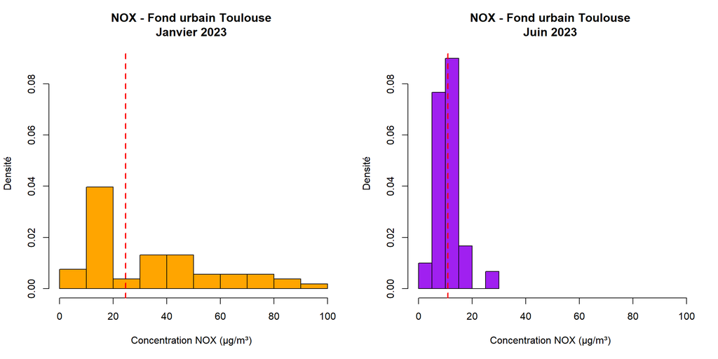

```r
nox_janv <- pb2_nox$valeur_poll[pb2_nox$mois == 1]
nox_juin <- pb2_nox$valeur_poll[pb2_nox$mois == 6]

h1 <- hist(nox_janv, plot = FALSE)
h2 <- hist(nox_juin, plot = FALSE)
xlim <- c(0, max(c(nox_janv, nox_juin), na.rm = TRUE))
ylim <- c(0, max(c(h1$density, h2$density)))

par(mfrow = c(1, 2))
hist(nox_janv, probability = TRUE, col = "orange", xlim = xlim, ylim = ylim,
     main = "NOX - Fond urbain Toulouse\nJanvier 2023",
     xlab = "Concentration NOX (µg/m³)", ylab = "Densité")
abline(v = median(nox_janv), col = "red", lwd = 2, lty = 2)
hist(nox_juin, probability = TRUE, col = "purple", xlim = xlim, ylim = ylim,
     main = "NOX - Fond urbain Toulouse\nJuin 2023",
     xlab = "Concentration NOX (µg/m³)", ylab = "Densité")
abline(v = median(nox_juin), col = "red", lwd = 2, lty = 2)
```

```r
par(mfrow = c(1, 1))
```

```r
cat("Résumé :\n")
```

```
## Résumé :
```

```r
cat("  NOX janvier - médiane =", round(median(nox_janv), 1), "µg/m³\n")
```

```
##   NOX janvier - médiane = 24.7 µg/m³
```

```r
cat("  NOX juin    - médiane =", round(median(nox_juin), 1), "µg/m³\n")
```

```
##   NOX juin    - médiane = 10.9 µg/m³
```

```r
cat("  Rapport janvier/juin  =", round(median(nox_janv) / median(nox_juin), 1), "\n")
```

```
##   Rapport janvier/juin  = 2.3
```

# 7 Problématique 3 : Existe-t-il un lien entre le niveau de vie et l’exposition à la pollution ?

## 7.1 Affinement de la problématique

On calcule la concentration moyenne de NO2 par commune pour l’année 2023, puis on croise cette valeur avec trois indicateurs socio-économiques : niveau_vie_median_2021, pourcentage_locataires_residence_principale_2022 et taux_activite_15_64_2022.

## 7.2 Résumé de la table

```r
summary(pb3)
```

```
##            nom_com      no2_moy        niveau_vie_median_2021
##  Agde          : 1   Min.   : 0.4942   16830.0: 1
##  Albi          : 1   1st Qu.: 8.6775   17380.0: 1
##  Alès          : 1   Median :10.2736   18000.0: 1
##  Argelès-Gazost: 1   Mean   :12.1831   18760.0: 1
##  Auch          : 1   3rd Qu.:14.9857   18810.0: 1
##  Béziers       : 1   Max.   :25.6380   19070.0: 1
##  (Other)       :14                     (Other):14
##  pourcentage_locataires_residence_principale_2022 taux_activite_15_64_2022
##  Min.   :19.40                                    Min.   :62.80
##  1st Qu.:43.05                                    1st Qu.:66.92
##  Median :52.70                                    Median :71.60
##  Mean   :48.97                                    Mean   :70.92
##  3rd Qu.:57.55                                    3rd Qu.:74.22
##  Max.   :66.70                                    Max.   :82.40
##
```

## 7.3 Préparation des données

```r
pb3_clean <- pb3[pb3$niveau_vie_median_2021 != "N/A - secret statistique", ]
pb3_clean$niveau_vie <- as.numeric(as.character(pb3_clean$niveau_vie_median_2021))
pb3_clean$pct_locataires <- pb3_clean$pourcentage_locataires_residence_principale_2022
pb3_clean$taux_activite <- pb3_clean$taux_activite_15_64_2022

cat("Communes retenues :", nrow(pb3_clean), "\n")
```

```
## Communes retenues : 19
```

```r
cat("Commune exclue (secret statistique) : Peyrusse-Vieille\n")
```

```
## Commune exclue (secret statistique) : Peyrusse-Vieille
```

## 7.4 Tableau récapitulatif trié par NO2 décroissant

```r
tab3 <- pb3_clean[order(-pb3_clean$no2_moy),
                   c("nom_com", "no2_moy", "niveau_vie", "pct_locataires", "taux_activite")]
tab3$no2_moy <- round(tab3$no2_moy, 1)
colnames(tab3) <- c("Commune", "NO2 moy.", "Niv. vie (€)", "% locataires", "Taux activité")
print(tab3, row.names = FALSE)
```

```
##         Commune NO2 moy. Niv. vie (€) % locataires Taux activité
##        Toulouse     25.6        22140         65.8          71.8
##       Perpignan     25.1        17380         56.9          62.9
##     Montpellier     24.7        19670         66.7          67.1
##           Nîmes     18.6        18760         57.4          66.4
##         Béziers     16.6        16830         58.0          63.4
##         Blagnac     14.4        25350         53.1          80.3
##            Alès     12.1        18000         59.2          62.8
##       Montauban     12.1        21630         43.5          72.7
##          Tarbes     11.0        19070         64.0          64.8
##           Rodez     10.3        22210         54.0          72.1
##            Albi     10.3        21650         52.3          68.1
##            Auch     10.0        21800         54.4          71.4
##         Lourdes      9.7        18810         49.6          68.9
##  Argelès-Gazost      9.1        21770         40.8          74.2
##      Lunel-Viel      9.0        21680         33.7          78.4
##    Saint-Girons      7.8        20320         45.7          74.3
##         Castres      6.2        20940         43.4          72.0
##     Montgiscard      5.4        27200         19.5          82.4
##            Agde      5.2        20410         42.0          68.7
```

En lisant le tableau, on constate que les trois communes ayant le NO2 moyen le plus élevé (Toulouse, Perpignan, Montpellier) présentent toutes un pourcentage de locataires supérieur à 55 % et un niveau de vie médian inférieur à 22 200 €. À l’inverse, les communes en bas du tableau (Montgiscard, Agde) ont un faible taux de locataires.

## 7.5 Nuage de points : niveau de vie vs NO2

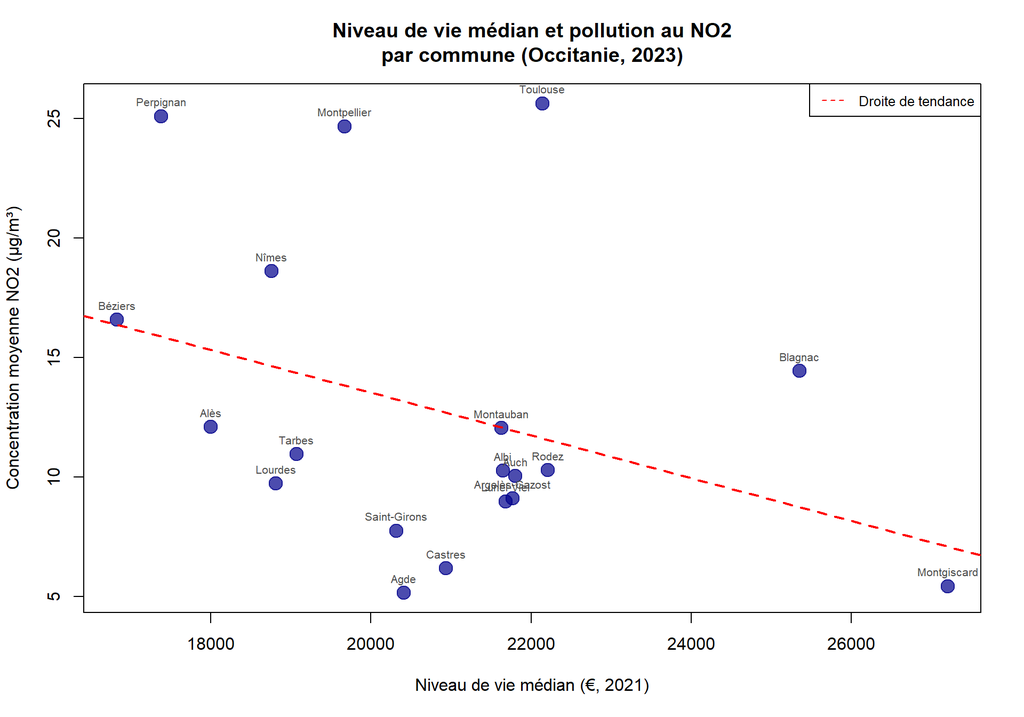

```r
plot(pb3_clean$niveau_vie, pb3_clean$no2_moy,
     pch = 19, col = adjustcolor("darkblue", alpha = 0.7), cex = 1.8,
     xlab = "Niveau de vie médian (€, 2021)",
     ylab = "Concentration moyenne NO2 (µg/m³)",
     main = "Niveau de vie médian et pollution au NO2\npar commune (Occitanie, 2023)")
text(pb3_clean$niveau_vie, pb3_clean$no2_moy,
     labels = pb3_clean$nom_com, pos = 3, cex = 0.65, col = "gray30")
abline(lm(no2_moy ~ niveau_vie, data = pb3_clean), col = "red", lty = 2, lwd = 2)
legend("topright", legend = "Droite de tendance", col = "red", lty = 2, cex = 0.8)
```

## 7.6 Nuage de points : pourcentage de locataires vs NO2

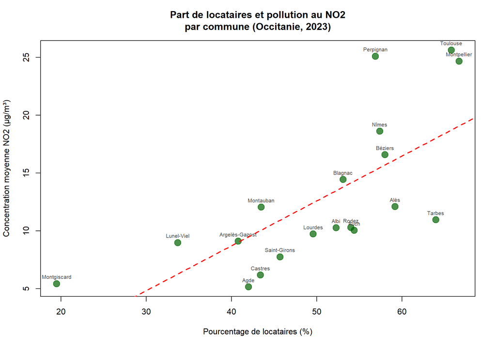

```r
plot(pb3_clean$pct_locataires, pb3_clean$no2_moy,
     pch = 19, col = adjustcolor("darkgreen", alpha = 0.7), cex = 1.8,
     xlab = "Pourcentage de locataires (%)",
     ylab = "Concentration moyenne NO2 (µg/m³)",
     main = "Part de locataires et pollution au NO2\npar commune (Occitanie, 2023)")
text(pb3_clean$pct_locataires, pb3_clean$no2_moy,
     labels = pb3_clean$nom_com, pos = 3, cex = 0.65, col = "gray30")
abline(lm(no2_moy ~ pct_locataires, data = pb3_clean), col = "red", lty = 2, lwd = 2)
```

## 7.7 Nuage de points : taux d’activité vs NO2

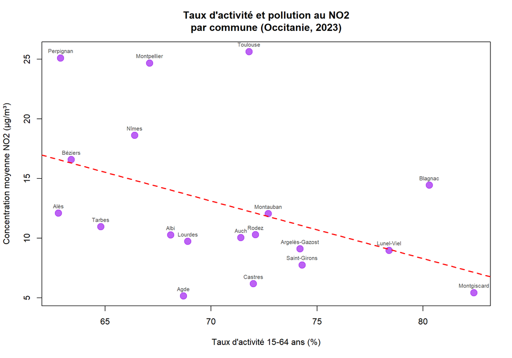

```r
plot(pb3_clean$taux_activite, pb3_clean$no2_moy,
     pch = 19, col = adjustcolor("purple", alpha = 0.7), cex = 1.8,
     xlab = "Taux d'activité 15-64 ans (%)",
     ylab = "Concentration moyenne NO2 (µg/m³)",
     main = "Taux d'activité et pollution au NO2\npar commune (Occitanie, 2023)")
text(pb3_clean$taux_activite, pb3_clean$no2_moy,
     labels = pb3_clean$nom_com, pos = 3, cex = 0.65, col = "gray30")
abline(lm(no2_moy ~ taux_activite, data = pb3_clean), col = "red", lty = 2, lwd = 2)
```

## 7.8 Conclusion de la problématique 3

Parmi les trois variables socio-économiques étudiées, le pourcentage de locataires est celle qui présente l’association la plus visible avec le NO2 moyen : le nuage de points montre une tendance croissante assez nette. Le niveau de vie médian montre une tendance décroissante mais plus faible, avec davantage de dispersion. Le taux d’activité ne montre pas de tendance claire. D’un point de vue descriptif, la variable pourcentage_locataires apparaît donc comme l’indicateur socio-économique le plus associé aux niveaux de NO2 parmi ceux étudiés.

# 8 Problématique 4 : Les conditions géo-climatiques expliquent-elles les différences de pollution ?

## 8.1 Affinement de la problématique

On calcule la concentration moyenne de NO2 par commune pour l’année 2023, puis on croise cette valeur avec six variables géo-climatiques : alti_med, Force_vent_med, Tmax_med, Insolation_med, RR_med et densite.

## 8.2 Résumé de la table

```r
summary(pb4)
```

```
##  code_insee_com            nom_com      no2_moy           alti_med
##  Min.   : 9261   Agde          : 1   Min.   : 0.4942   Min.   :  2.00
##  1st Qu.:31303   Albi          : 1   1st Qu.: 8.6775   1st Qu.: 48.75
##  Median :34018   Alès          : 1   Median :10.2736   Median :162.50
##  Mean   :44121   Argelès-Gazost: 1   Mean   :12.1831   Mean   :194.25
##  3rd Qu.:65325   Auch          : 1   3rd Qu.:14.9857   3rd Qu.:256.50
##  Max.   :82121   Béziers       : 1   Max.   :25.6380   Max.   :590.00
##                  (Other)       :14
##  Force_vent_med     Tmax_med     Insolation_med     RR_med
##  Min.   :2.000   Min.   :15.60   Min.   :3031   Min.   :29.25
##  1st Qu.:2.350   1st Qu.:18.10   1st Qu.:3216   1st Qu.:47.04
##  Median :2.700   Median :18.90   Median :3472   Median :55.60
##  Mean   :2.855   Mean   :18.81   Mean   :3682   Mean   :55.66
##  3rd Qu.:3.350   3rd Qu.:19.50   3rd Qu.:4126   3rd Qu.:65.70
##  Max.   :4.500   Max.   :20.70   Max.   :4690   Max.   :83.00
##
##     densite
##  Min.   :   6.0
##  1st Qu.: 369.0
##  Median : 879.5
##  Mean   :1328.8
##  3rd Qu.:1785.5
##  Max.   :5296.0
##
```

## 8.3 Tableau récapitulatif trié par NO2 décroissant

```r
tab4 <- pb4[order(-pb4$no2_moy),
            c("nom_com", "no2_moy", "alti_med", "Force_vent_med", "Tmax_med",
              "Insolation_med", "RR_med", "densite")]
tab4$no2_moy <- round(tab4$no2_moy, 1)
colnames(tab4) <- c("Commune", "NO2 moy.", "Altitude", "Vent (m/s)",
                     "Tmax (°C)", "Insolation", "Pluie (mm)", "Densité")
print(tab4, row.names = FALSE)
```

```
##           Commune NO2 moy. Altitude Vent (m/s) Tmax (°C) Insolation Pluie (mm)
##          Toulouse     25.6      144        3.6     18.10     3378.0      52.50
##         Perpignan     25.1       42        4.5     19.45     4099.0      29.25
##       Montpellier     24.7       45        2.6     19.00     4690.0      44.00
##             Nîmes     18.6       39        3.3     19.50     4324.5      74.50
##           Béziers     16.6       50        4.0     19.50     4299.0      48.05
##           Blagnac     14.4      151        3.6     18.10     3378.0      49.65
##              Alès     12.1      185        2.8     20.70     3865.5      54.70
##         Montauban     12.1      115        2.2     18.60     3433.0      65.00
##            Tarbes     11.0      360        2.5     17.40     3156.0      83.00
##             Rodez     10.3      590        3.5     15.60     3672.5      66.30
##              Albi     10.3      167        2.4     18.60     3511.5      62.75
##              Auch     10.0      158        2.0     18.90     3218.0      56.50
##           Lourdes      9.7      360        2.5     18.50     3156.0      57.65
##    Argelès-Gazost      9.1      446        2.0     18.90     3156.0      67.80
##        Lunel-Viel      9.0        6        2.5     20.40     4205.0      44.00
##      Saint-Girons      7.8      391        2.0     17.50     3208.5      38.30
##           Castres      6.2      222        2.1     20.40     3031.0      68.80
##       Montgiscard      5.4      190        2.9     19.40     3982.0      54.65
##              Agde      5.2        2        3.2     19.55     4530.5      30.40
##  Peyrusse-Vieille      0.5      222        2.9     18.10     3343.0      65.50
##  Densité
##     4269
##     1752
##     5296
##      919
##      840
##     1539
##     1886
##      456
##     2867
##     2142
##     1106
##      314
##      366
##      919
##      370
##      328
##      432
##      196
##      572
##        6
```

En haut du tableau (communes avec le NO2 le plus élevé), on observe des valeurs de densité élevées et des altitudes basses. En bas du tableau, on retrouve des communes à faible densité.

## 8.4 Nuage de points : densité vs NO2

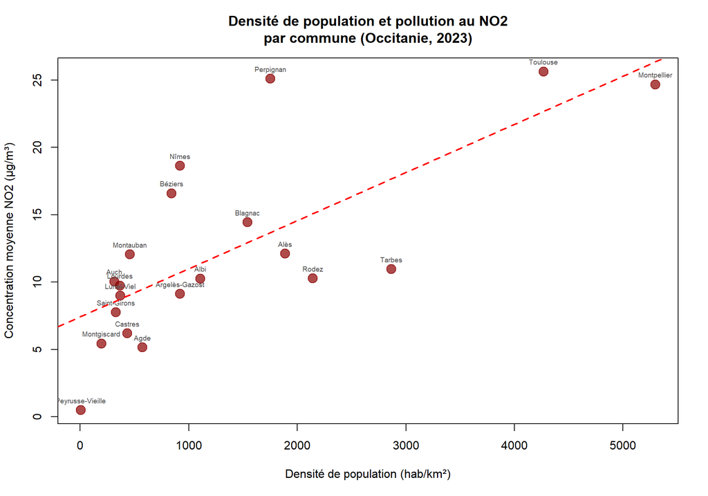

```r
plot(pb4$densite, pb4$no2_moy,
     pch = 19, col = adjustcolor("darkred", alpha = 0.7), cex = 1.8,
     xlab = "Densité de population (hab/km²)",
     ylab = "Concentration moyenne NO2 (µg/m³)",
     main = "Densité de population et pollution au NO2\npar commune (Occitanie, 2023)")
text(pb4$densite, pb4$no2_moy,
     labels = pb4$nom_com, pos = 3, cex = 0.6, col = "gray30")
abline(lm(no2_moy ~ densite, data = pb4), col = "red", lty = 2, lwd = 2)
```

Le nuage de points montre une tendance croissante marquée : la droite de tendance a une pente positive, et les communes à forte densité (Montpellier à 5296, Toulouse à 4269 hab/km²) se trouvent clairement dans la partie supérieure du graphique, tandis que les communes à faible densité (Peyrusse-Vieille à 6 hab/km²) sont en bas. Parmi les variables étudiées, la densité semble être celle qui présente l’association la plus forte avec le NO2 moyen.

## 8.5 Nuage de points : altitude vs NO2

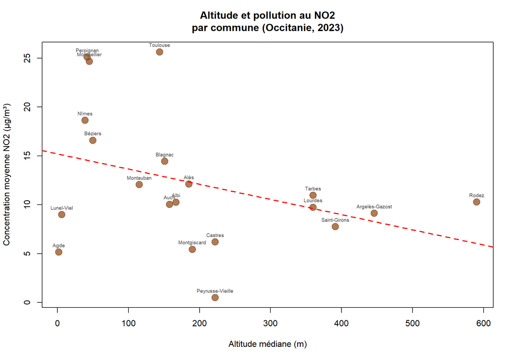

```r
plot(pb4$alti_med, pb4$no2_moy,
     pch = 19, col = adjustcolor("saddlebrown", alpha = 0.7), cex = 1.8,
     xlab = "Altitude médiane (m)",
     ylab = "Concentration moyenne NO2 (µg/m³)",
     main = "Altitude et pollution au NO2\npar commune (Occitanie, 2023)")
text(pb4$alti_med, pb4$no2_moy,
     labels = pb4$nom_com, pos = 3, cex = 0.6, col = "gray30")
abline(lm(no2_moy ~ alti_med, data = pb4), col = "red", lty = 2, lwd = 2)
```

La droite de tendance présente une pente négative : les communes situées en basse altitude tendent à avoir un NO2 moyen plus élevé, tandis que celles en altitude (Rodez à 590 m, Argelès-Gazost à 446 m) affichent des valeurs plus basses. La dispersion des points reste cependant importante.

## 8.6 Nuage de points : force du vent vs NO2

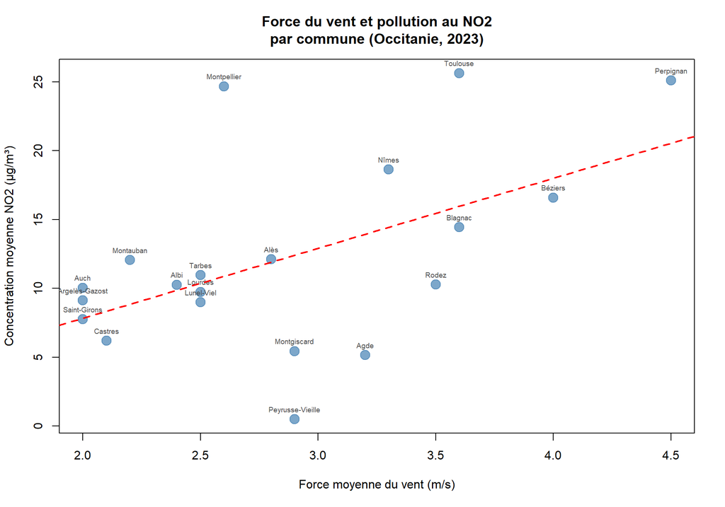

```r
plot(pb4$Force_vent_med, pb4$no2_moy,
     pch = 19, col = adjustcolor("steelblue", alpha = 0.7), cex = 1.8,
     xlab = "Force moyenne du vent (m/s)",
     ylab = "Concentration moyenne NO2 (µg/m³)",
     main = "Force du vent et pollution au NO2\npar commune (Occitanie, 2023)")
text(pb4$Force_vent_med, pb4$no2_moy,
     labels = pb4$nom_com, pos = 3, cex = 0.6, col = "gray30")
abline(lm(no2_moy ~ Force_vent_med, data = pb4), col = "red", lty = 2, lwd = 2)
```

La relation entre la force du vent et le NO2 est difficile à interpréter sur ce graphique. La droite de tendance montre une légère pente positive, mais les points sont très dispersés. Par exemple, Perpignan (4.5 m/s) a un NO2 très élevé, tandis que d’autres communes peu ventées comme Auch (2.0 m/s) ont un NO2 modéré. La variable vent seule ne suffit donc pas à discriminer les communes polluées des moins polluées, d’autres variables jouant un rôle simultané.

## 8.7 Nuage de points : précipitations vs NO2

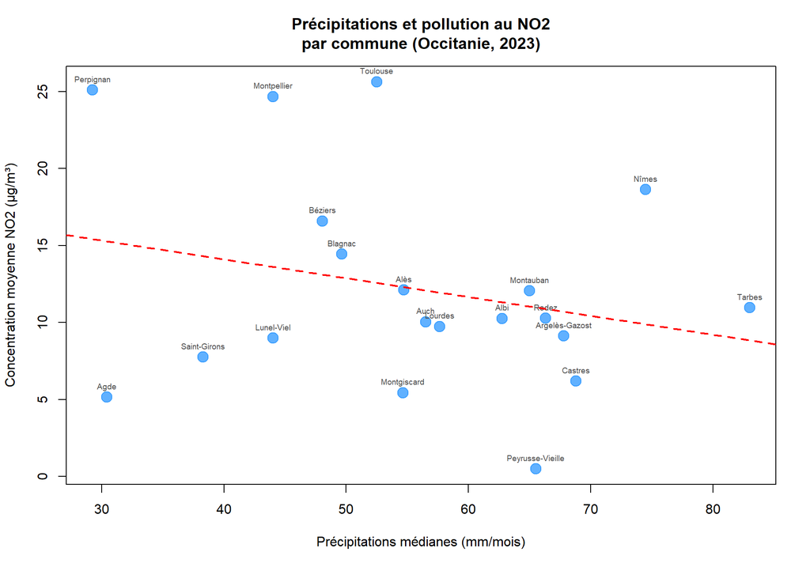

```r
plot(pb4$RR_med, pb4$no2_moy,
     pch = 19, col = adjustcolor("dodgerblue", alpha = 0.7), cex = 1.8,
     xlab = "Précipitations médianes (mm/mois)",
     ylab = "Concentration moyenne NO2 (µg/m³)",
     main = "Précipitations et pollution au NO2\npar commune (Occitanie, 2023)")
text(pb4$RR_med, pb4$no2_moy,
     labels = pb4$nom_com, pos = 3, cex = 0.6, col = "gray30")
abline(lm(no2_moy ~ RR_med, data = pb4), col = "red", lty = 2, lwd = 2)
```

On observe une légère tendance décroissante : la droite de tendance a une pente négative, indiquant que les communes avec davantage de précipitations tendent à avoir un NO2 plus faible. Cependant, la dispersion des points reste importante, et cette tendance est donc à considérer avec prudence.

## 8.8 Nuage de points : ensoleillement vs NO2

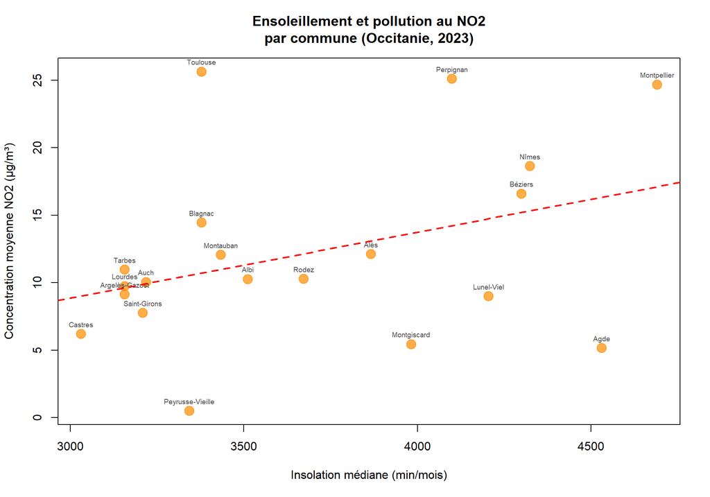

```r
plot(pb4$Insolation_med, pb4$no2_moy,
     pch = 19, col = adjustcolor("darkorange", alpha = 0.7), cex = 1.8,
     xlab = "Insolation médiane (min/mois)",
     ylab = "Concentration moyenne NO2 (µg/m³)",
     main = "Ensoleillement et pollution au NO2\npar commune (Occitanie, 2023)")
text(pb4$Insolation_med, pb4$no2_moy,
     labels = pb4$nom_com, pos = 3, cex = 0.6, col = "gray30")
abline(lm(no2_moy ~ Insolation_med, data = pb4), col = "red", lty = 2, lwd = 2)
```

La droite de tendance montre une légère pente positive, mais les points sont très dispersés autour de cette droite. Par exemple, Montpellier (insolation élevée à 4690 min/mois) et Perpignan (4099 min/mois) ont un NO2 élevé, mais Agde (4530 min/mois), avec une insolation comparable, a un NO2 beaucoup plus faible. La variable ensoleillement seule ne permet donc pas de distinguer les communes polluées des moins polluées dans nos données.

# 9 Conclusion générale

Cette analyse par statistique descriptive a permis de dégager les observations suivantes :

Ces résultats, obtenus uniquement par des outils de statistique descriptive (tableaux d’indicateurs, boîtes à moustaches, histogrammes, nuages de points), constituent des observations factuelles qui mériteraient d’être approfondies par des méthodes d’analyse complémentaires.